# Large-Scale and Online Kernel Methods: Exercise solutions

Course: Machine Learning II, Data Science Master (Universidad de Cantabria - UIMP).  
Lecturers: Steven Van Vaerenbergh, Ignacio Santamaria.

```python
import numpy as np
import pandas as pd
import matplotlib.pyplot as plt

# inline plots
%matplotlib inline
```

## Exercise: Kernel Ridge Regression with Nyström and RFF transforms

Apply approximate kernel ridge regression to the KIN40K data. Compare the results of the Nyström and RFF approximations.

A good starting value for the $\gamma$ parameter of the RBF kernel is $\gamma=1/2$. Find a fitting value for the parameter "n_components".

```python
from scipy.io import loadmat

kin40k = loadmat('data/kin40k.mat')

X = kin40k['X']
y = kin40k['y']

print('Data shape:\nX: %s\ny: %s\n'%(X.shape,y.shape))

# apply scaling with coefficients learned by Gaussian processes
loghyper = loadmat('data/kin40k_loghyper.mat')

# convert log values to normal range
scalers = np.exp(loghyper['loghyper'][0:8]).ravel()

# divide features by scaling coefficients
X /= scalers
```

```
Data shape:
X: (40000, 8)
y: (40000, 1)
```

```python
from sklearn.model_selection import train_test_split

X_train, X_test, y_train, y_test = \
    train_test_split(X, y, test_size=0.75, random_state=42)

print('Training data shape:\nX_train: %s\ny_train: %s\n'%(X_train.shape,y_train.shape))
print('Test data shape:\nX_test: %s\ny_test: %s'%(X_test.shape,y_test.shape))
```

```
Training data shape:
X_train: (10000, 8)
y_train: (10000, 1)

Test data shape:
X_test: (30000, 8)
y_test: (30000, 1)
```

```python
from sklearn.kernel_approximation import Nystroem
from sklearn.kernel_approximation import RBFSampler
from sklearn.linear_model import LinearRegression

from sklearn import pipeline
from sklearn.metrics import mean_squared_error
```

```python
# TO DO: change the following lines to properly define the regressors

# define parameters
gamma = 1/2
n_components_nystroem = 500
n_components_fourier = 1000

# define feature maps
feature_map_nystroem = Nystroem(gamma=gamma, n_components=n_components_nystroem, random_state=0)
feature_map_fourier = RBFSampler(gamma=gamma, n_components=n_components_fourier, random_state=0)

# define pipelines
nystroem_approx_krr = pipeline.Pipeline([("feature_map", feature_map_nystroem),
                                        ("ridge", LinearRegression())])
fourier_approx_krr = pipeline.Pipeline([("feature_map", feature_map_fourier),
                                        ("ridge", LinearRegression())])

# The next lines should not be changed:

# train the regressors
nystroem_approx_krr.fit(X_train,y_train)
fourier_approx_krr.fit(X_train,y_train)

# test the regressors
y_pred_nystroem = nystroem_approx_krr.predict(X_test)
y_pred_fourier = fourier_approx_krr.predict(X_test)

# calculate mean square error
mse_nystroem = mean_squared_error(y_test, y_pred_nystroem)
mse_fourier = mean_squared_error(y_test, y_pred_fourier)

# print MSE values in standard scale and dB scale
print('MSE for Nyström: %.4f'%mse_nystroem)
print('MSE for RFF: %.4f\n'%mse_fourier)
print('MSE (dB) for Nyström: %.4f'%(10*np.log10(mse_nystroem)))
print('MSE (dB) for RFF: %.4f'%(10*np.log10(mse_fourier)))
```

```
MSE for Nyström: 0.1161
MSE for RFF: 0.0935

MSE (dB) for Nyström: -9.3512
MSE (dB) for RFF: -10.2940
```

## Exercise: Fixed-Budget Kernel Least Mean Squares

The dictionary size can be limited by curbing its growth, which is what the coherence criterion is used for. An alternative way of limiting the dictionary size is by *removing* bases that are less relevant. In practice, we will start removing bases from the dictionary (and their corresponding coefficients from alpha) once the dictionary reaches a predefined size.

In this exercise you will implement a modified KLMS algorithm that includes dictionary pruning:

1. Modify the KLMS algorithm: In `__init__()`, add a parameter `max_bases` that indicates the maximum size of the dictionary.
2. In the `fit()` method, add a check to see if the dictionary size has reached the maximum. If this is the case, remove the dictionary element that corresponds to the coefficient of alpha with the lowest absolute value. Prune the dictionary element and the corresponding alpha coefficient.
3. Obtain the learning curve of this algorithm to KLMS and KNLMS.
4. Describe the results.

```python
from time import time
```

```
Data shape:
x: (4996, 1)
y: (4996, 1)
```

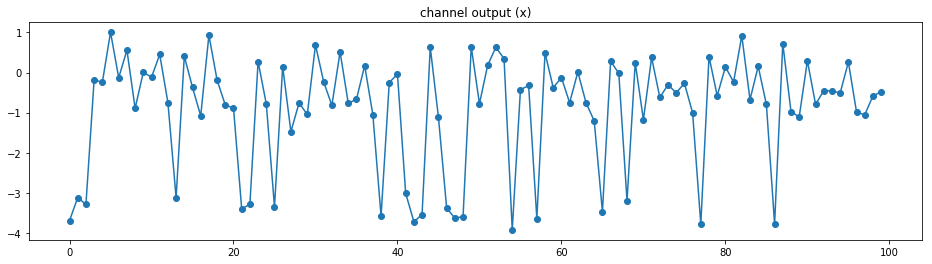

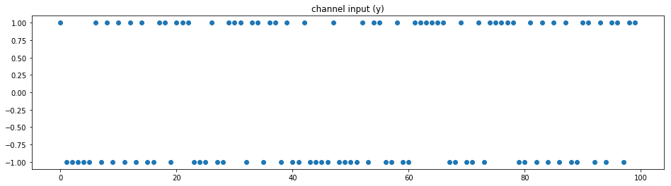

```python
channel_data = loadmat('data/nonlinear_channel_eq.mat')

x = channel_data['x']
y = channel_data['y']

n_samples = len(x)

print('Data shape:\nx: %s\ny: %s\n'%(x.shape,y.shape))

plt.figure(figsize=(16,4))
plt.plot(x[0:100],'-o')
plt.title('channel output (x)')
plt.show()

plt.figure(figsize=(16,4))
plt.plot(y[0:100],'o')
plt.title('channel input (y)')
plt.show()
```

```python
# add embedding to input

embedding = 5

# time embedding
X = np.zeros((n_samples,embedding))
for i in np.arange(0,embedding):
    X[i:,i] = x[0:n_samples-i].ravel()
```

```python
# define train and test size
n_tr = 2000
n_te = 50

X_train = X[0:n_tr]
y_train = y[0:n_tr]

X_test = X[n_tr:n_tr+n_te]
y_test = y[n_tr:n_tr+n_te]
```

```python
from sklearn.gaussian_process.kernels import RBF

class KLMS(object):
    """Kernel Least Mean Squares algorithm"""
    def __init__(self, mu=0.5, kernel=RBF()):
        self.mu = mu
        self.kernel = kernel

    def init_attr(self, input_dim):
        """Initialize attributes"""
        self.alpha_ = np.empty((0,), float)
        self.dict = np.empty((0,input_dim), float)

    def fit_single(self,x,y):
        """Train for one datum"""
        if not hasattr(self, 'dict'):
            # initialize
            self.init_attr(x.shape[0])

        err = y - self.predict(x)
        update = self.mu * err
        self.alpha_ = np.hstack((self.alpha_,update))
        self.dict = np.vstack((self.dict,x))

    def predict(self, X):
        """Predict outputs"""
        K = self.kernel.__call__(X,self.dict)
        return np.dot(K,self.alpha_)
```

```python
class KNLMS(object):
    """Kernel Normalised Least Mean Squares algorithm"""
    def __init__(self, eta=0.5, mu0=0.8, eps=1E-2, kernel=RBF()):
        self.eta = eta # step size
        self.mu0 = mu0 # coherence threshold
        self.eps = eps # regularization
        self.kernel = kernel

    def init_attr(self, input_dim):
        """Initialize attributes"""
        self.alpha_ = np.empty((0,), float)
        self.dict = np.empty((0,input_dim), float)

    def fit_single(self,x,y):
        """Train for one datum"""
        if not hasattr(self, 'dict'):
            # initialize
            self.init_attr(x.shape[0])

            self.dict = np.vstack((self.dict,x))
            self.alpha_ = np.hstack((self.alpha_,0))
        else:
            k = self.kernel.__call__(x,self.dict)
            if np.amax(k) < self.mu0:
                self.dict = np.vstack((self.dict,x))
                self.alpha_ = np.hstack((self.alpha_,0))

        k = np.squeeze(np.asarray(self.kernel.__call__(x,self.dict)))
        err = y - self.predict(x)

        # update alpha
        self.alpha_ = self.alpha_ + self.eta / (self.eps + np.dot(k,k)) * err * k;
        self.alpha_ = self.alpha_.ravel()

    def predict(self, X):
        """Predict outputs"""
        K = self.kernel.__call__(X,self.dict)
        return np.dot(K,self.alpha_)
```

```python
# 1. and 2. Implement the modified KLMS algorithm

class SFBKLMS(object):
    """Simple Fixed Budget Kernel Least Mean Squares algorithm"""
    def __init__(self, mu=0.5, max_bases=1000, kernel=RBF()):
        self.mu = mu
        self.max_bases = max_bases
        self.kernel = kernel

    def init_attr(self, input_dim):
        """Initialize attributes"""
        self.alpha_ = np.empty((0,), float)
        self.dict = np.empty((0,input_dim), float)

    def fit_single(self,x,y):
        """Train for one datum"""
        if not hasattr(self, 'dict'):
            # initialize
            self.init_attr(x.shape[0])

        if self.dict.shape[0] >= self.max_bases:
            # prune
            idx = np.argmin(np.absolute(self.alpha_))
            self.alpha_ = np.delete(self.alpha_,idx)
            self.dict = np.delete(self.dict,idx,0)

        err = y - self.predict(x)
        update = self.mu * err
        self.alpha_ = np.hstack((self.alpha_,update))
        self.dict = np.vstack((self.dict,x))

    def predict(self, X):
        """Predict outputs"""
        K = self.kernel.__call__(X,self.dict)
        return np.dot(K,self.alpha_)
```

```
Training KNLMS...
Elapsed time: 2.94 s.
Final dictionary size: 206 bases.

Training KLMS...
Elapsed time: 7.13 s.
Final dictionary size: 2000 bases.

Training SFBKLMS...
Elapsed time: 4.09 s.
Final dictionary size: 500 bases.
```

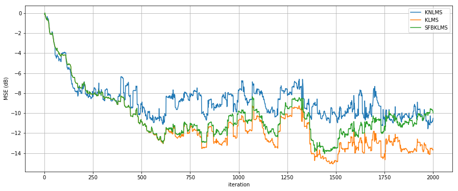

```python
# 3. If required, modify the  algorithm parameters. Obtain the learning curves.

# define the predictors

knlms = KNLMS(eta=0.5, mu0=0.5, kernel=RBF(length_scale=1))
klms = KLMS(mu=0.5, kernel=RBF(length_scale=1))

# add this parameter to the method
max_bases = 500
sfbklms = SFBKLMS(mu=0.5, max_bases=max_bases, kernel=RBF(length_scale=1))

predictors = [knlms, klms, sfbklms]
#predictors = [sfbklms]

plt.figure(figsize=(15,6))

for predictor in predictors:

    mse_all = []

    pname = predictor.__class__.__name__
    print('Training %s...'%pname)

    start = time()
    for xi, yi in zip(X_train, y_train):

        # train on new datum
        predictor.fit_single(xi,yi)

        # predict output
        y_pred = predictor.predict(X_test)
        mse = mean_squared_error(y_test, y_pred)
        mse_all.append(mse)

    predictor_time = time() - start

    print('Elapsed time: %.2f s.'%predictor_time)

    print('Final dictionary size: %d bases.\n'%predictor.dict.shape[0])

    plt.plot(range(1, len(mse_all) + 1), 10*np.log10(mse_all), label=pname)

plt.xlabel('iteration')
plt.ylabel('MSE (dB)')
plt.legend()
plt.grid(True)
plt.show()
```

```python
# 4. Describe the result of the modified KLMS algorithm:
# Did you find a parameter setting that produces good results?
# Do the results hold if you raise n_tr?
# Is this algorithm an improvement of KLMS?
```